# IMPORTING LIBRARIES

```python
import pandas as pd
import numpy as np
import matplotlib.pyplot as plt
import seaborn as sb
sb.set()
%matplotlib inline

import warnings
warnings.filterwarnings(action='ignore')
```

# IMPORTING THE DATASET

```python
Cancer_DR=pd.read_csv('total-cancer-deaths-by-type.csv')#pd.read_csv() imports the data into the notebook in csv format(note: this will only work if the data itself is in csv format.)
Cancer_DR
```

|  | Entity | Code | Year | Deaths - Liver cancer - Sex: Both - Age: All Ages (Number) | Deaths - Kidney cancer - Sex: Both - Age: All Ages (Number) | Deaths - Lip and oral cavity cancer - Sex: Both - Age: All Ages (Number) | Deaths - Tracheal, bronchus, and lung cancer - Sex: Both - Age: All Ages (Number) | Deaths - Larynx cancer - Sex: Both - Age: All Ages (Number) | Deaths - Gallbladder and biliary tract cancer - Sex: Both - Age: All Ages (Number) | Deaths - Malignant skin melanoma - Sex: Both - Age: All Ages (Number) | ... | Deaths - Brain and central nervous system cancer - Sex: Both - Age: All Ages (Number) | Deaths - Non-Hodgkin lymphoma - Sex: Both - Age: All Ages (Number) | Deaths - Pancreatic cancer - Sex: Both - Age: All Ages (Number) | Deaths - Esophageal cancer - Sex: Both - Age: All Ages (Number) | Deaths - Testicular cancer - Sex: Both - Age: All Ages (Number) | Deaths - Nasopharynx cancer - Sex: Both - Age: All Ages (Number) | Deaths - Other pharynx cancer - Sex: Both - Age: All Ages (Number) | Deaths - Colon and rectum cancer - Sex: Both - Age: All Ages (Number) | Deaths - Non-melanoma skin cancer - Sex: Both - Age: All Ages (Number) | Deaths - Mesothelioma - Sex: Both - Age: All Ages (Number) |
| --- | --- | --- | --- | --- | --- | --- | --- | --- | --- | --- | --- | --- | --- | --- | --- | --- | --- | --- | --- | --- | --- |
| 0 | Afghanistan | AFG | 1990 | 851 | 66 | 89 | 983 | 260 | 180 | 47 | ... | 422 | 996 | 138 | 529 | 3 | 66 | 37 | 539 | 25 | 6 |
| 1 | Afghanistan | AFG | 1991 | 866 | 66 | 89 | 982 | 263 | 182 | 48 | ... | 438 | 1010 | 137 | 535 | 4 | 67 | 37 | 542 | 26 | 7 |
| 2 | Afghanistan | AFG | 1992 | 890 | 68 | 91 | 989 | 268 | 185 | 51 | ... | 472 | 1040 | 137 | 546 | 4 | 69 | 38 | 550 | 26 | 7 |
| 3 | Afghanistan | AFG | 1993 | 914 | 70 | 93 | 995 | 275 | 189 | 53 | ... | 505 | 1062 | 139 | 560 | 5 | 72 | 39 | 555 | 27 | 7 |
| 4 | Afghanistan | AFG | 1994 | 933 | 71 | 94 | 996 | 282 | 193 | 54 | ... | 526 | 1069 | 140 | 575 | 5 | 73 | 39 | 554 | 28 | 8 |
| ... | ... | ... | ... | ... | ... | ... | ... | ... | ... | ... | ... | ... | ... | ... | ... | ... | ... | ... | ... | ... | ... |
| 8005 | Zimbabwe | ZWE | 2015 | 948 | 59 | 145 | 902 | 149 | 87 | 125 | ... | 104 | 96 | 426 | 988 | 11 | 53 | 40 | 719 | 39 | 16 |
| 8006 | Zimbabwe | ZWE | 2016 | 966 | 61 | 150 | 932 | 153 | 89 | 129 | ... | 109 | 100 | 449 | 1012 | 11 | 54 | 42 | 744 | 40 | 17 |
| 8007 | Zimbabwe | ZWE | 2017 | 982 | 63 | 154 | 960 | 156 | 91 | 133 | ... | 112 | 102 | 471 | 1035 | 12 | 56 | 43 | 767 | 41 | 17 |
| 8008 | Zimbabwe | ZWE | 2018 | 998 | 66 | 159 | 993 | 160 | 92 | 137 | ... | 115 | 105 | 495 | 1059 | 12 | 57 | 44 | 792 | 43 | 17 |
| 8009 | Zimbabwe | ZWE | 2019 | 1016 | 68 | 164 | 1026 | 165 | 95 | 141 | ... | 118 | 108 | 517 | 1087 | 12 | 59 | 45 | 818 | 44 | 18 |

8010 rows × 32 columns

# DATA INFORMATION

In this part, we will get to know every information about the dataset; like the numerical features, the categorical features, the missing values, value counts, unique values.

## DATA SHAPE

```python
print(Cancer_DR.shape)#This shows the shape(number of rows and columns) present in the dataset
print('The data contains 8010 rows and 32 columns')
```

```
(8010, 32)
The data contains 8010 rows and 32 columns
```

## FEATURE/COLUMN NAMES

```python
Cancer_DR.columns#Prints out all the column(features) in the dataset
```

```
Index(['Entity', 'Code', 'Year',
       'Deaths - Liver cancer - Sex: Both - Age: All Ages (Number)',
       'Deaths - Kidney cancer - Sex: Both - Age: All Ages (Number)',
       'Deaths - Lip and oral cavity cancer - Sex: Both - Age: All Ages (Number)',
       'Deaths - Tracheal, bronchus, and lung cancer - Sex: Both - Age: All Ages (Number)',
       'Deaths - Larynx cancer - Sex: Both - Age: All Ages (Number)',
       'Deaths - Gallbladder and biliary tract cancer - Sex: Both - Age: All Ages (Number)',
       'Deaths - Malignant skin melanoma - Sex: Both - Age: All Ages (Number)',
       'Deaths - Leukemia - Sex: Both - Age: All Ages (Number)',
       'Deaths - Hodgkin lymphoma - Sex: Both - Age: All Ages (Number)',
       'Deaths - Multiple myeloma - Sex: Both - Age: All Ages (Number)',
       'Deaths - Other neoplasms - Sex: Both - Age: All Ages (Number)',
       'Deaths - Breast cancer - Sex: Both - Age: All Ages (Number)',
       'Deaths - Prostate cancer - Sex: Both - Age: All Ages (Number)',
       'Deaths - Thyroid cancer - Sex: Both - Age: All Ages (Number)',
       'Deaths - Stomach cancer - Sex: Both - Age: All Ages (Number)',
       'Deaths - Bladder cancer - Sex: Both - Age: All Ages (Number)',
       'Deaths - Uterine cancer - Sex: Both - Age: All Ages (Number)',
       'Deaths - Ovarian cancer - Sex: Both - Age: All Ages (Number)',
       'Deaths - Cervical cancer - Sex: Both - Age: All Ages (Number)',
       'Deaths - Brain and central nervous system cancer - Sex: Both - Age: All Ages (Number)',
       'Deaths - Non-Hodgkin lymphoma - Sex: Both - Age: All Ages (Number)',
       'Deaths - Pancreatic cancer - Sex: Both - Age: All Ages (Number)',
       'Deaths - Esophageal cancer - Sex: Both - Age: All Ages (Number)',
       'Deaths - Testicular cancer - Sex: Both - Age: All Ages (Number)',
       'Deaths - Nasopharynx cancer - Sex: Both - Age: All Ages (Number)',
       'Deaths - Other pharynx cancer - Sex: Both - Age: All Ages (Number)',
       'Deaths - Colon and rectum cancer - Sex: Both - Age: All Ages (Number)',
       'Deaths - Non-melanoma skin cancer - Sex: Both - Age: All Ages (Number)',
       'Deaths - Mesothelioma - Sex: Both - Age: All Ages (Number)'],
      dtype='object')
```

## DATA INFO/TYPES

```python
Cancer_DR.info()#This shows the number of values that are non-null(not missing) and the data type of each feature(column)
```

```
<class 'pandas.core.frame.DataFrame'>
RangeIndex: 8010 entries, 0 to 8009
Data columns (total 32 columns):
 #   Column                                                                                 Non-Null Count  Dtype
---  ------                                                                                 --------------  -----
 0   Entity                                                                                 8010 non-null   object
 1   Code                                                                                   6150 non-null   object
 2   Year                                                                                   8010 non-null   int64
 3   Deaths - Liver cancer - Sex: Both - Age: All Ages (Number)                             8010 non-null   int64
 4   Deaths - Kidney cancer - Sex: Both - Age: All Ages (Number)                            8010 non-null   int64
 5   Deaths - Lip and oral cavity cancer - Sex: Both - Age: All Ages (Number)               8010 non-null   int64
 6   Deaths - Tracheal, bronchus, and lung cancer - Sex: Both - Age: All Ages (Number)      8010 non-null   int64
 7   Deaths - Larynx cancer - Sex: Both - Age: All Ages (Number)                            8010 non-null   int64
 8   Deaths - Gallbladder and biliary tract cancer - Sex: Both - Age: All Ages (Number)     8010 non-null   int64
 9   Deaths - Malignant skin melanoma - Sex: Both - Age: All Ages (Number)                  8010 non-null   int64
```

[output cut: 24 more lines]

The above shows that the data is made up of 30 numerical features(int64-integers) and 2 categorical features(object)

## CHECKING FOR MISSING VALUES

```python
Cancer_DR.isnull().sum()#This shows the sum of missing values in each feature of the dataset
```

```
Entity                                                                                      0
Code                                                                                     1860
Year                                                                                        0
Deaths - Liver cancer - Sex: Both - Age: All Ages (Number)                                  0
Deaths - Kidney cancer - Sex: Both - Age: All Ages (Number)                                 0
Deaths - Lip and oral cavity cancer - Sex: Both - Age: All Ages (Number)                    0
Deaths - Tracheal, bronchus, and lung cancer - Sex: Both - Age: All Ages (Number)           0
Deaths - Larynx cancer - Sex: Both - Age: All Ages (Number)                                 0
Deaths - Gallbladder and biliary tract cancer - Sex: Both - Age: All Ages (Number)          0
Deaths - Malignant skin melanoma - Sex: Both - Age: All Ages (Number)                       0
Deaths - Leukemia - Sex: Both - Age: All Ages (Number)                                      0
Deaths - Hodgkin lymphoma - Sex: Both - Age: All Ages (Number)                              0
Deaths - Multiple myeloma - Sex: Both - Age: All Ages (Number)                              0
Deaths - Other neoplasms - Sex: Both - Age: All Ages (Number)                               0
Deaths - Breast cancer - Sex: Both - Age: All Ages (Number)                                 0
Deaths - Prostate cancer - Sex: Both - Age: All Ages (Number)                               0
Deaths - Thyroid cancer - Sex: Both - Age: All Ages (Number)                                0
Deaths - Stomach cancer - Sex: Both - Age: All Ages (Number)                                0
Deaths - Bladder cancer - Sex: Both - Age: All Ages (Number)                                0
Deaths - Uterine cancer - Sex: Both - Age: All Ages (Number)                                0
Deaths - Ovarian cancer - Sex: Both - Age: All Ages (Number)                                0
Deaths - Cervical cancer - Sex: Both - Age: All Ages (Number)                               0
Deaths - Brain and central nervous system cancer - Sex: Both - Age: All Ages (Number)       0
Deaths - Non-Hodgkin lymphoma - Sex: Both - Age: All Ages (Number)                          0
Deaths - Pancreatic cancer - Sex: Both - Age: All Ages (Number)                             0
Deaths - Esophageal cancer - Sex: Both - Age: All Ages (Number)                             0
Deaths - Testicular cancer - Sex: Both - Age: All Ages (Number)                             0
Deaths - Nasopharynx cancer - Sex: Both - Age: All Ages (Number)                            0
Deaths - Other pharynx cancer - Sex: Both - Age: All Ages (Number)                          0
Deaths - Colon and rectum cancer - Sex: Both - Age: All Ages (Number)                       0
Deaths - Non-melanoma skin cancer - Sex: Both - Age: All Ages (Number)                      0
Deaths - Mesothelioma - Sex: Both - Age: All Ages (Number)                                  0
dtype: int64
```

There are 1860 missing values in the 'Code' column. The 'Code'column is the column that contains codes of individual countries and regions from the 'Entity' column which is a list of countries/continents/territories/groups.

We can treat the missing values by filling in the respective codes for the different countries/regions/continents/groups e.t.c

## CATEGORICAL FEATURES

```python
nunique_entity=Cancer_DR['Entity'].nunique()#This shows the total number of unique values in the 'Entity' column
nunique_code=Cancer_DR['Code'].nunique()#This shows the total number of unique values in the 'Code' column
print('Total number of values in Entity: ',nunique_entity)
print('Total number of values in Code: ',nunique_code)
```

```
Total number of values in Entity:  267
Total number of values in Code:  205
```

```python
Cancer_DR['Entity'].unique()#This prints the unique values in the 'Entity' column, i.e each individual value. (NOTE: the 'Entity' column contains country names and some other groups like the 'World Bank Low Income' Countries)
```

```
array(['Afghanistan', 'Africa', 'African Region', 'African Union',
       'Albania', 'Algeria', 'America', 'American Samoa',
       'Andean Latin America', 'Andorra', 'Angola', 'Antigua and Barbuda',
       'Argentina', 'Armenia', 'Asia', 'Australasia', 'Australia',
       'Austria', 'Azerbaijan', 'Bahamas', 'Bahrain', 'Bangladesh',
       'Barbados', 'Belarus', 'Belgium', 'Belize', 'Benin', 'Bermuda',
       'Bhutan', 'Bolivia', 'Bosnia and Herzegovina', 'Botswana',
       'Brazil', 'Brunei', 'Bulgaria', 'Burkina Faso', 'Burundi',
       'Cambodia', 'Cameroon', 'Canada', 'Cape Verde', 'Caribbean',
       'Central African Republic', 'Central Asia', 'Central Europe',
       'Central Europe, Eastern Europe, and Central Asia',
       'Central Latin America', 'Central sub-Saharan Africa', 'Chad',
       'Chile', 'China', 'Colombia', 'Commonwealth',
       'Commonwealth High Income', 'Commonwealth Low Income',
       'Commonwealth Middle Income', 'Comoros', 'Congo', 'Cook Islands',
       'Costa Rica', "Cote d'Ivoire", 'Croatia', 'Cuba', 'Cyprus',
       'Czechia', 'Democratic Republic of Congo', 'Denmark', 'Djibouti',
       'Dominica', 'Dominican Republic', 'East Asia',
       'East Asia & Pacific - World Bank region', 'Eastern Europe',
       'Eastern Mediterranean Region', 'Eastern sub-Saharan Africa',
       'Ecuador', 'Egypt', 'El Salvador', 'England', 'Equatorial Guinea',
       'Eritrea', 'Estonia', 'Eswatini', 'Ethiopia', 'Europe',
       'Europe & Central Asia - World Bank region', 'European Region',
       'European Union', 'Fiji', 'Finland', 'France', 'G20', 'Gabon',
       'Gambia', 'Georgia', 'Germany', 'Ghana', 'Greece', 'Greenland',
       'Grenada', 'Guam', 'Guatemala', 'Guinea', 'Guinea-Bissau',
       'Guyana', 'Haiti', 'High SDI', 'High-income',
       'High-income Asia Pacific', 'High-income North America',
       'High-middle SDI', 'Honduras', 'Hungary', 'Iceland', 'India',
       'Indonesia', 'Iran', 'Iraq', 'Ireland', 'Israel', 'Italy',
       'Jamaica', 'Japan', 'Jordan', 'Kazakhstan', 'Kenya', 'Kiribati',
       'Kuwait', 'Kyrgyzstan', 'Laos',
       'Latin America & Caribbean - World Bank region', 'Latvia',
       'Lebanon', 'Lesotho', 'Liberia', 'Libya', 'Lithuania', 'Low SDI',
       'Low-middle SDI', 'Luxembourg', 'Madagascar', 'Malawi', 'Malaysia',
       'Maldives', 'Mali', 'Malta', 'Marshall Islands', 'Mauritania',
       'Mauritius', 'Mexico', 'Micronesia (country)',
       'Middle East & North Africa', 'Middle SDI', 'Moldova', 'Monaco',
       'Mongolia', 'Montenegro', 'Morocco', 'Mozambique', 'Myanmar',
       'Namibia', 'Nauru', 'Nepal', 'Netherlands', 'New Zealand',
```

[output cut: 13 more lines]

```
       'South-East Asia Region', 'Southeast Asia',
       'Southeast Asia, East Asia, and Oceania', 'Southern Latin America',
       'Southern sub-Saharan Africa', 'Spain', 'Sri Lanka',
       'Sub-Saharan Africa - World Bank region', 'Sudan', 'Suriname',
       'Sweden', 'Switzerland', 'Syria', 'Taiwan', 'Tajikistan',
       'Tanzania', 'Thailand', 'Timor', 'Togo', 'Tokelau', 'Tonga',
       'Trinidad and Tobago', 'Tropical Latin America', 'Tunisia',
       'Turkey', 'Turkmenistan', 'Tuvalu', 'Uganda', 'Ukraine',
       'United Arab Emirates', 'United Kingdom', 'United States',
       'United States Virgin Islands', 'Uruguay', 'Uzbekistan', 'Vanuatu',
       'Venezuela', 'Vietnam', 'Wales', 'Western Europe',
       'Western Pacific Region', 'Western sub-Saharan Africa', 'World',
       'World Bank High Income', 'World Bank Low Income',
       'World Bank Lower Middle Income', 'World Bank Upper Middle Income',
       'Yemen', 'Zambia', 'Zimbabwe'], dtype=object)
```

```python
Cancer_DR['Code'].unique()#This prints the unique values in the 'Code' column, i.e the codes for Afghanistan and Yemen are AFG and YEM respectively
```

```
array(['AFG', nan, 'ALB', 'DZA', 'ASM', 'AND', 'AGO', 'ATG', 'ARG', 'ARM',
       'AUS', 'AUT', 'AZE', 'BHS', 'BHR', 'BGD', 'BRB', 'BLR', 'BEL',
       'BLZ', 'BEN', 'BMU', 'BTN', 'BOL', 'BIH', 'BWA', 'BRA', 'BRN',
       'BGR', 'BFA', 'BDI', 'KHM', 'CMR', 'CAN', 'CPV', 'CAF', 'TCD',
       'CHL', 'CHN', 'COL', 'COM', 'COG', 'COK', 'CRI', 'CIV', 'HRV',
       'CUB', 'CYP', 'CZE', 'COD', 'DNK', 'DJI', 'DMA', 'DOM', 'ECU',
       'EGY', 'SLV', 'GNQ', 'ERI', 'EST', 'SWZ', 'ETH', 'FJI', 'FIN',
       'FRA', 'GAB', 'GMB', 'GEO', 'DEU', 'GHA', 'GRC', 'GRL', 'GRD',
       'GUM', 'GTM', 'GIN', 'GNB', 'GUY', 'HTI', 'HND', 'HUN', 'ISL',
       'IND', 'IDN', 'IRN', 'IRQ', 'IRL', 'ISR', 'ITA', 'JAM', 'JPN',
       'JOR', 'KAZ', 'KEN', 'KIR', 'KWT', 'KGZ', 'LAO', 'LVA', 'LBN',
       'LSO', 'LBR', 'LBY', 'LTU', 'LUX', 'MDG', 'MWI', 'MYS', 'MDV',
       'MLI', 'MLT', 'MHL', 'MRT', 'MUS', 'MEX', 'FSM', 'MDA', 'MCO',
       'MNG', 'MNE', 'MAR', 'MOZ', 'MMR', 'NAM', 'NRU', 'NPL', 'NLD',
       'NZL', 'NIC', 'NER', 'NGA', 'NIU', 'PRK', 'MKD', 'MNP', 'NOR',
       'OMN', 'PAK', 'PLW', 'PSE', 'PAN', 'PNG', 'PRY', 'PER', 'PHL',
       'POL', 'PRT', 'PRI', 'QAT', 'ROU', 'RUS', 'RWA', 'KNA', 'LCA',
       'VCT', 'WSM', 'SMR', 'STP', 'SAU', 'SEN', 'SRB', 'SYC', 'SLE',
       'SGP', 'SVK', 'SVN', 'SLB', 'SOM', 'ZAF', 'KOR', 'SSD', 'ESP',
       'LKA', 'SDN', 'SUR', 'SWE', 'CHE', 'SYR', 'TWN', 'TJK', 'TZA',
       'THA', 'TLS', 'TGO', 'TKL', 'TON', 'TTO', 'TUN', 'TUR', 'TKM',
       'TUV', 'UGA', 'UKR', 'ARE', 'GBR', 'USA', 'VIR', 'URY', 'UZB',
       'VUT', 'VEN', 'VNM', 'OWID_WRL', 'YEM', 'ZMB', 'ZWE'], dtype=object)
```

There are 267 unique values of Entities in the dataset, and 205 for Codes. 62 unique values for 'Code' are missing, we will work on them soon, might also drop the 'Code' feature.

Remember the 'Entity' is made up of different countries,continents,teritories(cannot be classified as countries),Islands,regions,groups. There are 196 countries in the World, including the United Kingdom which contains 4 other countries; England, Scotland, Northern Ireland and Wales. China also claims Taiwan(Country) as its province.

Apart from the 197 countries present, the 'Entity' column also contains continents like; Africa, Asia, Europe, North America, Oceania.

We also have groups like; World(all continents), World Bank High Income/Low Income, World Bank Lower/Upper Middle Income,OECD Countries, Caribbean, Commonwealth, Commonwealth High/Low/Middle income, etc.

## NUMERICAL FEATURES

1. Deaths - Liver cancer - Sex: Both - Age: All Ages (Number)
2. Deaths - Kidney cancer - Sex: Both - Age: All Ages (Number)
3. Deaths - Lip and oral cavity cancer - Sex: Both - Age: All Ages (Number)
4. Deaths - Tracheal, bronchus, and lung cancer - Sex: Both - Age: All Ages (Number)
5. Deaths - Larynx cancer - Sex: Both - Age: All Ages (Number)
6. Deaths - Gallbladder and biliary tract cancer - Sex: Both - Age: All Ages (Number)
7. Deaths - Malignant skin melanoma - Sex: Both - Age: All Ages (Number)
8. Deaths - Leukemia - Sex: Both - Age: All Ages (Number)
9. Deaths - Hodgkin lymphoma - Sex: Both - Age: All Ages (Number)
10. Deaths - Multiple myeloma - Sex: Both - Age: All Ages (Number)
11. Deaths - Other neoplasms - Sex: Both - Age: All Ages (Number)
12. Deaths - Breast cancer - Sex: Both - Age: All Ages (Number)
13. Deaths - Prostate cancer - Sex: Both - Age: All Ages (Number)
14. Deaths - Thyroid cancer - Sex: Both - Age: All Ages (Number)
15. Deaths - Stomach cancer - Sex: Both - Age: All Ages (Number)
16. Deaths - Bladder cancer - Sex: Both - Age: All Ages (Number)
17. Deaths - Uterine cancer - Sex: Both - Age: All Ages (Number)
18. Deaths - Ovarian cancer - Sex: Both - Age: All Ages (Number)
19. Deaths - Cervical cancer - Sex: Both - Age: All Ages (Number)
20. Deaths - Brain and central nervous system cancer - Sex: Both - Age: All Ages (Number)
21. Deaths - Non-Hodgkin lymphoma - Sex: Both - Age: All Ages (Number)
22. Deaths - Pancreatic cancer - Sex: Both - Age: All Ages (Number)
23. Deaths - Esophageal cancer - Sex: Both - Age: All Ages (Number)
24. Deaths - Testicular cancer - Sex: Both - Age: All Ages (Number)
25. Deaths - Nasopharynx cancer - Sex: Both - Age: All Ages (Number)
26. Deaths - Other pharynx cancer - Sex: Both - Age: All Ages (Number)
27. Deaths - Colon and rectum cancer - Sex: Both - Age: All Ages (Number)
28. Deaths - Non-melanoma skin cancer - Sex: Both - Age: All Ages (Number)
29. Deaths - Mesothelioma - Sex: Both - Age: All Ages (Number)

We will be changinging the headers of the Cancer Death Rate dateset to more understandable ones (shorter and readable names).

# EXPLORATORY DATA ANALYSIS (EDA)

## CHECKING FOR DUPLICATES

```python
Cancer_DR=Cancer_DR.drop_duplicates(keep='last')#This checks for and drop duplicates in a dataset
Cancer_DR
```

|  | Entity | Code | Year | Deaths - Liver cancer - Sex: Both - Age: All Ages (Number) | Deaths - Kidney cancer - Sex: Both - Age: All Ages (Number) | Deaths - Lip and oral cavity cancer - Sex: Both - Age: All Ages (Number) | Deaths - Tracheal, bronchus, and lung cancer - Sex: Both - Age: All Ages (Number) | Deaths - Larynx cancer - Sex: Both - Age: All Ages (Number) | Deaths - Gallbladder and biliary tract cancer - Sex: Both - Age: All Ages (Number) | Deaths - Malignant skin melanoma - Sex: Both - Age: All Ages (Number) | ... | Deaths - Brain and central nervous system cancer - Sex: Both - Age: All Ages (Number) | Deaths - Non-Hodgkin lymphoma - Sex: Both - Age: All Ages (Number) | Deaths - Pancreatic cancer - Sex: Both - Age: All Ages (Number) | Deaths - Esophageal cancer - Sex: Both - Age: All Ages (Number) | Deaths - Testicular cancer - Sex: Both - Age: All Ages (Number) | Deaths - Nasopharynx cancer - Sex: Both - Age: All Ages (Number) | Deaths - Other pharynx cancer - Sex: Both - Age: All Ages (Number) | Deaths - Colon and rectum cancer - Sex: Both - Age: All Ages (Number) | Deaths - Non-melanoma skin cancer - Sex: Both - Age: All Ages (Number) | Deaths - Mesothelioma - Sex: Both - Age: All Ages (Number) |
| --- | --- | --- | --- | --- | --- | --- | --- | --- | --- | --- | --- | --- | --- | --- | --- | --- | --- | --- | --- | --- | --- |
| 0 | Afghanistan | AFG | 1990 | 851 | 66 | 89 | 983 | 260 | 180 | 47 | ... | 422 | 996 | 138 | 529 | 3 | 66 | 37 | 539 | 25 | 6 |
| 1 | Afghanistan | AFG | 1991 | 866 | 66 | 89 | 982 | 263 | 182 | 48 | ... | 438 | 1010 | 137 | 535 | 4 | 67 | 37 | 542 | 26 | 7 |
| 2 | Afghanistan | AFG | 1992 | 890 | 68 | 91 | 989 | 268 | 185 | 51 | ... | 472 | 1040 | 137 | 546 | 4 | 69 | 38 | 550 | 26 | 7 |
| 3 | Afghanistan | AFG | 1993 | 914 | 70 | 93 | 995 | 275 | 189 | 53 | ... | 505 | 1062 | 139 | 560 | 5 | 72 | 39 | 555 | 27 | 7 |
| 4 | Afghanistan | AFG | 1994 | 933 | 71 | 94 | 996 | 282 | 193 | 54 | ... | 526 | 1069 | 140 | 575 | 5 | 73 | 39 | 554 | 28 | 8 |
| ... | ... | ... | ... | ... | ... | ... | ... | ... | ... | ... | ... | ... | ... | ... | ... | ... | ... | ... | ... | ... | ... |
| 8005 | Zimbabwe | ZWE | 2015 | 948 | 59 | 145 | 902 | 149 | 87 | 125 | ... | 104 | 96 | 426 | 988 | 11 | 53 | 40 | 719 | 39 | 16 |
| 8006 | Zimbabwe | ZWE | 2016 | 966 | 61 | 150 | 932 | 153 | 89 | 129 | ... | 109 | 100 | 449 | 1012 | 11 | 54 | 42 | 744 | 40 | 17 |
| 8007 | Zimbabwe | ZWE | 2017 | 982 | 63 | 154 | 960 | 156 | 91 | 133 | ... | 112 | 102 | 471 | 1035 | 12 | 56 | 43 | 767 | 41 | 17 |
| 8008 | Zimbabwe | ZWE | 2018 | 998 | 66 | 159 | 993 | 160 | 92 | 137 | ... | 115 | 105 | 495 | 1059 | 12 | 57 | 44 | 792 | 43 | 17 |
| 8009 | Zimbabwe | ZWE | 2019 | 1016 | 68 | 164 | 1026 | 165 | 95 | 141 | ... | 118 | 108 | 517 | 1087 | 12 | 59 | 45 | 818 | 44 | 18 |

8010 rows × 32 columns

From the above, we still ave 8010 rows and 32 columns which means that there are no duplicates in the dataset.

## RENAMING HEADERS

```python
header_names=['Entity','Code','Year','Liver Cancer','Kidney Cancer','Lip and oral cavity cancer','Tracheal, bronchus, and lung cancer',
             'Larynx Cancer','Gallbladder and biliary tract cancer','Malignant Skin Cancer','Leukemia','Hodgkin Lymphoma','Multiple Myeloma',
             'Other Neoplasms','Breast Cancer','Prostrate Cancer','Thyroid Cancer','Stomach Cancer','Bladder Cancer','Uterine Cancer','Ovarian Cancer',
             'Cervical Cancer','Brain and central nervous system cancer','Non-Hodgkin Lymphoma','Pancreatic Cancer','Esophageal Cancer','Testicular Cancer',
             'Nasopharynx Cancer','Other Pharynx Cancer',' Colon and rectum cancer','Non-melanoma skin cancer','Mesothelioma']
Cancer_DR=pd.read_csv('total-cancer-deaths-by-type.csv', header=None,skiprows=1,names=header_names)
Cancer_DR
```

|  | Entity | Code | Year | Liver Cancer | Kidney Cancer | Lip and oral cavity cancer | Tracheal, bronchus, and lung cancer | Larynx Cancer | Gallbladder and biliary tract cancer | Malignant Skin Cancer | ... | Brain and central nervous system cancer | Non-Hodgkin Lymphoma | Pancreatic Cancer | Esophageal Cancer | Testicular Cancer | Nasopharynx Cancer | Other Pharynx Cancer | Colon and rectum cancer | Non-melanoma skin cancer | Mesothelioma |
| --- | --- | --- | --- | --- | --- | --- | --- | --- | --- | --- | --- | --- | --- | --- | --- | --- | --- | --- | --- | --- | --- |
| 0 | Afghanistan | AFG | 1990 | 851 | 66 | 89 | 983 | 260 | 180 | 47 | ... | 422 | 996 | 138 | 529 | 3 | 66 | 37 | 539 | 25 | 6 |
| 1 | Afghanistan | AFG | 1991 | 866 | 66 | 89 | 982 | 263 | 182 | 48 | ... | 438 | 1010 | 137 | 535 | 4 | 67 | 37 | 542 | 26 | 7 |
| 2 | Afghanistan | AFG | 1992 | 890 | 68 | 91 | 989 | 268 | 185 | 51 | ... | 472 | 1040 | 137 | 546 | 4 | 69 | 38 | 550 | 26 | 7 |
| 3 | Afghanistan | AFG | 1993 | 914 | 70 | 93 | 995 | 275 | 189 | 53 | ... | 505 | 1062 | 139 | 560 | 5 | 72 | 39 | 555 | 27 | 7 |
| 4 | Afghanistan | AFG | 1994 | 933 | 71 | 94 | 996 | 282 | 193 | 54 | ... | 526 | 1069 | 140 | 575 | 5 | 73 | 39 | 554 | 28 | 8 |
| ... | ... | ... | ... | ... | ... | ... | ... | ... | ... | ... | ... | ... | ... | ... | ... | ... | ... | ... | ... | ... | ... |
| 8005 | Zimbabwe | ZWE | 2015 | 948 | 59 | 145 | 902 | 149 | 87 | 125 | ... | 104 | 96 | 426 | 988 | 11 | 53 | 40 | 719 | 39 | 16 |
| 8006 | Zimbabwe | ZWE | 2016 | 966 | 61 | 150 | 932 | 153 | 89 | 129 | ... | 109 | 100 | 449 | 1012 | 11 | 54 | 42 | 744 | 40 | 17 |
| 8007 | Zimbabwe | ZWE | 2017 | 982 | 63 | 154 | 960 | 156 | 91 | 133 | ... | 112 | 102 | 471 | 1035 | 12 | 56 | 43 | 767 | 41 | 17 |
| 8008 | Zimbabwe | ZWE | 2018 | 998 | 66 | 159 | 993 | 160 | 92 | 137 | ... | 115 | 105 | 495 | 1059 | 12 | 57 | 44 | 792 | 43 | 17 |
| 8009 | Zimbabwe | ZWE | 2019 | 1016 | 68 | 164 | 1026 | 165 | 95 | 141 | ... | 118 | 108 | 517 | 1087 | 12 | 59 | 45 | 818 | 44 | 18 |

8010 rows × 32 columns

## TOTAL NUMBER OF CANCER DEATHS FOR A PARTICULAR COUNTRY FROM 1990-2019

```python
Cancer_DR['Total Number of Deaths']=Cancer_DR.iloc[:,3:32].sum(axis=1)#iloc function locates rows and features by their indexes (';' specifies all rows, while '3:32' specifies column 3 to column 32. when counting columns, we always start count from zero(0))
Cancer_DR
```

|  | Entity | Code | Year | Liver Cancer | Kidney Cancer | Lip and oral cavity cancer | Tracheal, bronchus, and lung cancer | Larynx Cancer | Gallbladder and biliary tract cancer | Malignant Skin Cancer | ... | Non-Hodgkin Lymphoma | Pancreatic Cancer | Esophageal Cancer | Testicular Cancer | Nasopharynx Cancer | Other Pharynx Cancer | Colon and rectum cancer | Non-melanoma skin cancer | Mesothelioma | Total Number of Deaths |
| --- | --- | --- | --- | --- | --- | --- | --- | --- | --- | --- | --- | --- | --- | --- | --- | --- | --- | --- | --- | --- | --- |
| 0 | Afghanistan | AFG | 1990 | 851 | 66 | 89 | 983 | 260 | 180 | 47 | ... | 996 | 138 | 529 | 3 | 66 | 37 | 539 | 25 | 6 | 10386 |
| 1 | Afghanistan | AFG | 1991 | 866 | 66 | 89 | 982 | 263 | 182 | 48 | ... | 1010 | 137 | 535 | 4 | 67 | 37 | 542 | 26 | 7 | 10558 |
| 2 | Afghanistan | AFG | 1992 | 890 | 68 | 91 | 989 | 268 | 185 | 51 | ... | 1040 | 137 | 546 | 4 | 69 | 38 | 550 | 26 | 7 | 10894 |
| 3 | Afghanistan | AFG | 1993 | 914 | 70 | 93 | 995 | 275 | 189 | 53 | ... | 1062 | 139 | 560 | 5 | 72 | 39 | 555 | 27 | 7 | 11241 |
| 4 | Afghanistan | AFG | 1994 | 933 | 71 | 94 | 996 | 282 | 193 | 54 | ... | 1069 | 140 | 575 | 5 | 73 | 39 | 554 | 28 | 8 | 11484 |
| ... | ... | ... | ... | ... | ... | ... | ... | ... | ... | ... | ... | ... | ... | ... | ... | ... | ... | ... | ... | ... | ... |
| 8005 | Zimbabwe | ZWE | 2015 | 948 | 59 | 145 | 902 | 149 | 87 | 125 | ... | 96 | 426 | 988 | 11 | 53 | 40 | 719 | 39 | 16 | 10735 |
| 8006 | Zimbabwe | ZWE | 2016 | 966 | 61 | 150 | 932 | 153 | 89 | 129 | ... | 100 | 449 | 1012 | 11 | 54 | 42 | 744 | 40 | 17 | 11028 |
| 8007 | Zimbabwe | ZWE | 2017 | 982 | 63 | 154 | 960 | 156 | 91 | 133 | ... | 102 | 471 | 1035 | 12 | 56 | 43 | 767 | 41 | 17 | 11291 |
| 8008 | Zimbabwe | ZWE | 2018 | 998 | 66 | 159 | 993 | 160 | 92 | 137 | ... | 105 | 495 | 1059 | 12 | 57 | 44 | 792 | 43 | 17 | 11575 |
| 8009 | Zimbabwe | ZWE | 2019 | 1016 | 68 | 164 | 1026 | 165 | 95 | 141 | ... | 108 | 517 | 1087 | 12 | 59 | 45 | 818 | 44 | 18 | 11876 |

8010 rows × 33 columns

So now, we have added a new column added to the Cancer Death DataFrame which shows the total number of deaths for a country/region, in a particular year

## CANCER DEATH RATE IN THE WORLD FROM 1990-2019

```python
WRLD=Cancer_DR[Cancer_DR['Entity']=='World']#DataFrame of all te rows and columns about 'World' Entity
WRLD_Death=WRLD['Total Number of Deaths']#DataFrame of all te rows and columns about 'Total Number of Deaths' Entity
WRLD_Year=WRLD['Year']
WRLD_Data=pd.concat([WRLD_Year,WRLD_Death],axis=1)#This joins two DataFrames together, column by column(axis=1)
WRLD_Data.reset_index(inplace=True)#This resets the index of the concated DataFrames
#WRLD_Data
```

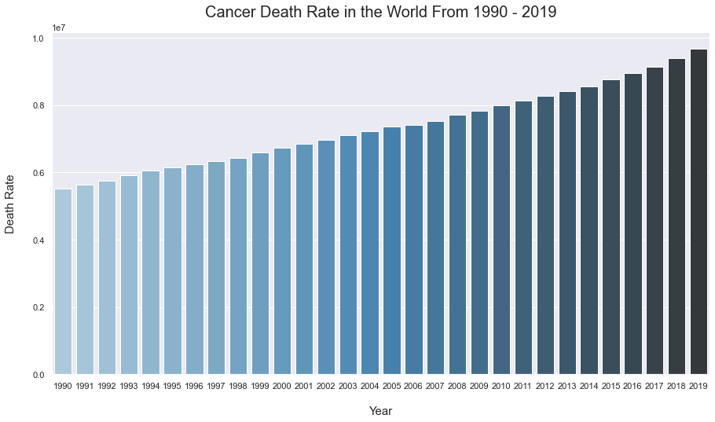

```python
plt.figure(figsize=(15,8))#This is the size you want your plot to have

sb.barplot(WRLD_Year,WRLD_Death,palette='Blues_d')
plt.title('Cancer Death Rate in the World From 1990 - 2019',pad=float(20),fontdict={'fontsize':float(20),'fontweight':int(2)})
plt.xlabel('Year',labelpad=float(20),fontdict={'fontsize':float(15),'fontweight':int(2)})
plt.ylabel('Death Rate',labelpad=float(20),fontdict={'fontsize':float(15),'fontweight':int(2)})
```

## TABULAR REPRESENTATION OF THE ABOVE BAR CHART

```python
percentage=[]
for i in WRLD_Data['Total Number of Deaths']:#For each value(i) in the column 'Total Number of Deaths'
    pct=i/WRLD_Data['Total Number of Deaths'].sum(axis=0) * 100 #That value(i)/sum of all the values in the column 'Total Number of Deaths'
    percentage.append(round(pct,2))#Adds pct to the list 'percentage=[]' and round it up to 2 Decimal places
WRLD_Data['Death %']=percentage#adds a new column 'Percentage' to the data frame

WRLD_Data.drop('index',axis=1,inplace=True)
WRLD_Data
```

|  | Year | Total Number of Deaths | Death % |
| --- | --- | --- | --- |
| 0 | 1990 | 5516590 | 2.50 |
| 1 | 1991 | 5628289 | 2.55 |
| 2 | 1992 | 5752640 | 2.61 |
| 3 | 1993 | 5919156 | 2.68 |
| 4 | 1994 | 6043965 | 2.74 |
| 5 | 1995 | 6147550 | 2.79 |
| 6 | 1996 | 6232438 | 2.83 |
| 7 | 1997 | 6324915 | 2.87 |
| 8 | 1998 | 6438820 | 2.92 |
| 9 | 1999 | 6589095 | 2.99 |
| 10 | 2000 | 6728924 | 3.05 |
| 11 | 2001 | 6837488 | 3.10 |
| 12 | 2002 | 6972810 | 3.16 |
| 13 | 2003 | 7102767 | 3.22 |
| 14 | 2004 | 7212867 | 3.27 |
| 15 | 2005 | 7354368 | 3.33 |
| 16 | 2006 | 7416652 | 3.36 |
| 17 | 2007 | 7537697 | 3.42 |
| 18 | 2008 | 7706312 | 3.49 |
| 19 | 2009 | 7840496 | 3.55 |
| 20 | 2010 | 7995757 | 3.62 |
| 21 | 2011 | 8128569 | 3.68 |
| 22 | 2012 | 8264980 | 3.75 |
| 23 | 2013 | 8402701 | 3.81 |
| 24 | 2014 | 8558547 | 3.88 |
| 25 | 2015 | 8764354 | 3.97 |
| 26 | 2016 | 8960182 | 4.06 |
| 27 | 2017 | 9145111 | 4.15 |
| 28 | 2018 | 9398540 | 4.26 |
| 29 | 2019 | 9671471 | 4.38 |

## CREATING A DATAFRAME FOR ALL CANCER TYPES AND THEIR RESPECTIVE NUMBER OF DEATHS (TOTAL NUMBER OF DEATHS FOR EACH CANCER TYPE) IN THE WORLD

```python
WCancerTypes=pd.DataFrame({'Cancer Type':['Liver Cancer','Kidney Cancer','Lip and oral cavity cancer','Tracheal, bronchus, and lung cancer',
             'Larynx Cancer','Gallbladder and biliary tract cancer','Malignant Skin Cancer','Leukemia','Hodgkin Lymphoma','Multiple Myeloma',
             'Other Neoplasms','Breast Cancer','Prostrate Cancer','Thyroid Cancer','Stomach Cancer','Bladder Cancer','Uterine Cancer','Ovarian Cancer',
             'Cervical Cancer','Brain and central nervous system cancer','Non-Hodgkin Lymphoma','Pancreatic Cancer','Esophageal Cancer','Testicular Cancer',
             'Nasopharynx Cancer','Other Pharynx Cancer',' Colon and rectum cancer','Non-melanoma skin cancer','Mesothelioma'],
                         'Number of Deaths':np.array(WRLD.iloc[:,3:32].sum(axis=0))})
```

[output not shown]

above is the total sum of all deaths caused by the various types of cancers in the world, from 1990 - 2019.

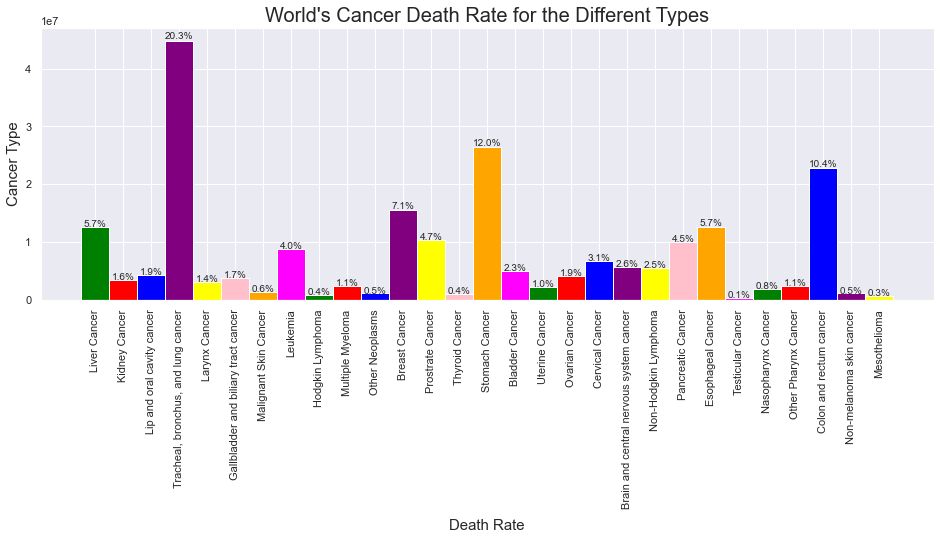

```python
#plt.figure(figsize=(7,10))
#sb.barplot(CancerTypes['Number of Deaths'],CancerTypes['Cancer Type'],orient='h',saturation=2)
#plt.title("World's Cancer Death Rate for the Different Types",fontdict={'fontsize':float(20),'fontweight':int(2)})
#plt.xlabel('Death Rate',labelpad=float(20),fontdict={'fontsize':float(15),'fontweight':int(2)})
#plt.ylabel('Cancer Type',fontdict={'fontsize':float(15),'fontweight':int(2)})

#ADDING PERCENTAGE TO THE PLOT
world_death_count=WCancerTypes['Number of Deaths'].sum(axis=0)
percentage=[]
for i in WCancerTypes['Number of Deaths']:
    pct=i/(WCancerTypes['Number of Deaths'].sum(axis=0)) * 100
    percentage.append(round(pct,1))
WCancerTypes['World %']=percentage

plt.figure(figsize=(16,5))
colors_list=['green','red','blue','purple','yellow','pink','orange','magenta']
cplot=plt.bar(WCancerTypes['Cancer Type'],WCancerTypes['Number of Deaths'],color=colors_list,width=1)

i=0
for p in cplot:
    width=p.get_width()
    height=p.get_height()
    x, y=p.get_xy()
    plt.text(x+width/2,y+height*1.01,str(WCancerTypes['World %'][i])+'%', ha='center')
    i+=1

plt.title("World's Cancer Death Rate for the Different Types",fontdict={'fontsize':float(20),'fontweight':int(2)})
plt.xlabel('Death Rate',labelpad=float(10),fontdict={'fontsize':float(15),'fontweight':int(2)})
plt.ylabel('Cancer Type',fontdict={'fontsize':float(15),'fontweight':int(2)})
plt.xticks(rotation=90)
plt.grid(True)
```

## TABULAR REPRESENTATION OF THE ABOVE BAR CHART

```python
WCancerTypes
```

|  | Cancer Type | Number of Deaths | World % |
| --- | --- | --- | --- |
| 0 | Liver Cancer | 12563680 | 5.7 |
| 1 | Kidney Cancer | 3432925 | 1.6 |
| 2 | Lip and oral cavity cancer | 4229580 | 1.9 |
| 3 | Tracheal, bronchus, and lung cancer | 44801914 | 20.3 |
| 4 | Larynx Cancer | 3052584 | 1.4 |
| 5 | Gallbladder and biliary tract cancer | 3853619 | 1.7 |
| 6 | Malignant Skin Cancer | 1423418 | 0.6 |
| 7 | Leukemia | 8769416 | 4.0 |
| 8 | Hodgkin Lymphoma | 802956 | 0.4 |
| 9 | Multiple Myeloma | 2371150 | 1.1 |
| 10 | Other Neoplasms | 1112218 | 0.5 |
| 11 | Breast Cancer | 15599266 | 7.1 |
| 12 | Prostrate Cancer | 10270999 | 4.7 |
| 13 | Thyroid Cancer | 986945 | 0.4 |
| 14 | Stomach Cancer | 26385742 | 12.0 |
| 15 | Bladder Cancer | 4992635 | 2.3 |
| 16 | Uterine Cancer | 2179138 | 1.0 |
| 17 | Ovarian Cancer | 4185747 | 1.9 |
| 18 | Cervical Cancer | 6764027 | 3.1 |
| 19 | Brain and central nervous system cancer | 5658693 | 2.6 |
| 20 | Non-Hodgkin Lymphoma | 5512153 | 2.5 |
| 21 | Pancreatic Cancer | 10009049 | 4.5 |
| 22 | Esophageal Cancer | 12606645 | 5.7 |
| 23 | Testicular Cancer | 259862 | 0.1 |
| 24 | Nasopharynx Cancer | 1813269 | 0.8 |
| 25 | Other Pharynx Cancer | 2337055 | 1.1 |
| 26 | Colon and rectum cancer | 22857330 | 10.4 |
| 27 | Non-melanoma skin cancer | 1113279 | 0.5 |
| 28 | Mesothelioma | 648757 | 0.3 |

**What could be the leading cause of Tracheal, bronchus, and lung cancer (TBL) in the world?**

1. Smoking tobacco
2. Secondhand smoke: inhaling the smoking of others
3. Arsenic in drinking water
4. other harmful air pollution.

## DATAFRAME FOR COUNTRIES IN SOUTH AMERICA

```python
brazil=Cancer_DR[Cancer_DR['Entity']=='Brazil']
argentina=Cancer_DR[Cancer_DR['Entity']=='Argentina']
colombia=Cancer_DR[Cancer_DR['Entity']=='Colombia']
chile=Cancer_DR[Cancer_DR['Entity']=='Chile']
peru=Cancer_DR[Cancer_DR['Entity']=='Peru']
venezuela=Cancer_DR[Cancer_DR['Entity']=='Venezuela']
ecuador=Cancer_DR[Cancer_DR['Entity']=='Ecuador']
bolivia=Cancer_DR[Cancer_DR['Entity']=='Bolivia']
paraguay=Cancer_DR[Cancer_DR['Entity']=='Paraguay']
uruguay=Cancer_DR[Cancer_DR['Entity']=='Uruguay']
guyana=Cancer_DR[Cancer_DR['Entity']=='Guyana']
suriname=Cancer_DR[Cancer_DR['Entity']=='Suriname']

SouthAmerica_DR=pd.concat([brazil,argentina,colombia,chile,peru,venezuela,ecuador,bolivia,paraguay,uruguay,guyana,suriname],ignore_index=True)
SouthAmerica_DR
```

|  | Entity | Code | Year | Liver Cancer | Kidney Cancer | Lip and oral cavity cancer | Tracheal, bronchus, and lung cancer | Larynx Cancer | Gallbladder and biliary tract cancer | Malignant Skin Cancer | ... | Non-Hodgkin Lymphoma | Pancreatic Cancer | Esophageal Cancer | Testicular Cancer | Nasopharynx Cancer | Other Pharynx Cancer | Colon and rectum cancer | Non-melanoma skin cancer | Mesothelioma | Total Number of Deaths |
| --- | --- | --- | --- | --- | --- | --- | --- | --- | --- | --- | --- | --- | --- | --- | --- | --- | --- | --- | --- | --- | --- |
| 0 | Brazil | BRA | 1990 | 1830 | 1418 | 2428 | 15661 | 2751 | 2913 | 916 | ... | 2992 | 4552 | 6134 | 233 | 218 | 1684 | 8340 | 782 | 383 | 111329 |
| 1 | Brazil | BRA | 1991 | 1848 | 1460 | 2475 | 15934 | 2783 | 2930 | 945 | ... | 3022 | 4631 | 6171 | 234 | 226 | 1726 | 8519 | 800 | 383 | 112827 |
| 2 | Brazil | BRA | 1992 | 1891 | 1516 | 2567 | 16526 | 2876 | 2996 | 991 | ... | 3100 | 4830 | 6323 | 241 | 238 | 1803 | 8929 | 828 | 392 | 116581 |
| 3 | Brazil | BRA | 1993 | 1948 | 1605 | 2712 | 17483 | 3040 | 3105 | 1060 | ... | 3257 | 5140 | 6590 | 245 | 254 | 1906 | 9610 | 868 | 405 | 122535 |
| 4 | Brazil | BRA | 1994 | 1991 | 1658 | 2811 | 18016 | 3121 | 3147 | 1111 | ... | 3359 | 5316 | 6713 | 248 | 267 | 1964 | 10061 | 909 | 408 | 126158 |
| ... | ... | ... | ... | ... | ... | ... | ... | ... | ... | ... | ... | ... | ... | ... | ... | ... | ... | ... | ... | ... | ... |
| 355 | Suriname | SUR | 2015 | 14 | 9 | 8 | 82 | 5 | 7 | 2 | ... | 20 | 36 | 8 | 1 | 5 | 3 | 83 | 3 | 1 | 605 |
| 356 | Suriname | SUR | 2016 | 15 | 9 | 8 | 85 | 5 | 7 | 3 | ... | 21 | 38 | 8 | 1 | 5 | 3 | 86 | 3 | 1 | 630 |
| 357 | Suriname | SUR | 2017 | 15 | 10 | 8 | 88 | 5 | 7 | 3 | ... | 22 | 39 | 8 | 1 | 5 | 3 | 89 | 3 | 1 | 646 |
| 358 | Suriname | SUR | 2018 | 16 | 10 | 9 | 90 | 5 | 7 | 3 | ... | 22 | 41 | 8 | 1 | 5 | 3 | 92 | 3 | 1 | 667 |
| 359 | Suriname | SUR | 2019 | 16 | 10 | 9 | 92 | 5 | 8 | 3 | ... | 23 | 43 | 9 | 1 | 5 | 3 | 94 | 3 | 1 | 685 |

360 rows × 33 columns

```python
SouthAmerica_DR.groupby(['Entity'])['Total Number of Deaths'].sum()
```

```
Entity
Argentina    2036050
Bolivia       262597
Brazil       5341976
Chile         659005
Colombia      997638
Ecuador       330725
Guyana         17478
Paraguay      112096
Peru          673970
Suriname       12946
Uruguay       265022
Venezuela     611890
Name: Total Number of Deaths, dtype: int64
```

```python
SouthAmerica=pd.DataFrame({'Entity':['Argentina','Bolivia','Brazil','Chile','Colombia','Ecuador','Guyana','Paraguay','Peru','Suriname','Uruguay','Venezuela'],
                                    'Deaths':[2036050,262597,5341976,659005,997638,330725,17478,112096,673970,12946,265022,611890]})

SouthAmerica_count=SouthAmerica.iloc[:,1].sum(axis=0)
SouthAmerica_count
```

```
11321393
```

## CREATING A DATAFRAME CALLED CONTINENTS

This is so that we can get the clear visualzation of the death rates from their respective continents when plotting graphs/bar charts et.c. We will call it the "Continents" dataset.

```python
Africa=Cancer_DR[Cancer_DR['Entity']=='Africa']#DataFrame of values in Africa
Asia=Cancer_DR[Cancer_DR['Entity']=='Asia']#DataFrame of values in Asia
Europe=Cancer_DR[Cancer_DR['Entity']=='Europe']#DataFrame of values in Europe
Oceania=Cancer_DR[Cancer_DR['Entity']=='Oceania']#DataFrame of values in Oceania
NorthAmerica=Cancer_DR[Cancer_DR['Entity']=='North America']#DataFrame of values in North America
Continents=pd.concat([Africa,Asia,Europe,Oceania,NorthAmerica],ignore_index=True)#This joins 2 or more DataFrames together
```

### Which Continent has the highest death rate?

```python
total=Continents.groupby(['Entity'])['Total Number of Deaths'].sum()#This groups all the entities together and calculate for thier respective sum
total
```

```
Entity
Africa            12656434
Asia             115131354
Europe            56755262
North America     20464717
Oceania             158580
Name: Total Number of Deaths, dtype: int64
```

```python
Continents=pd.DataFrame({'Entity':['Africa','Asia','Europe','North America','Oceania','South America'],
                              'Total Number of Deaths':[12656434,115131354,56755262,20464717,158580,11321393]})
Continents
```

|  | Entity | Total Number of Deaths |
| --- | --- | --- |
| 0 | Africa | 12656434 |
| 1 | Asia | 115131354 |
| 2 | Europe | 56755262 |
| 3 | North America | 20464717 |
| 4 | Oceania | 158580 |
| 5 | South America | 11321393 |

```python
total_death_count=Continents['Total Number of Deaths'].sum(axis=0)
print('Total Number of Deaths in the around the globe: ', total_death_count)
```

```
Total Number of Deaths in the around the globe:  216487740
```

```
 [Text(1.6222483590507004, -0.30134741007234545, 'Africa'),
 [Text(0.8848627413003819, -0.16437131458491566, '5.8%'),
```

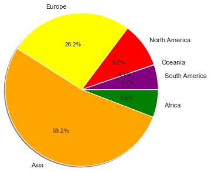

```python
plt.pie(Continents['Total Number of Deaths'],labels=Continents['Entity'],autopct='%1.1f%%',
        colors=['green','orange','yellow','red','blue','purple'],radius=1.5,counterclock=False,shadow=True,)
```

## DEATH RATE FOR THE DIFFERENT TYPES OF CANCER IN ASIA

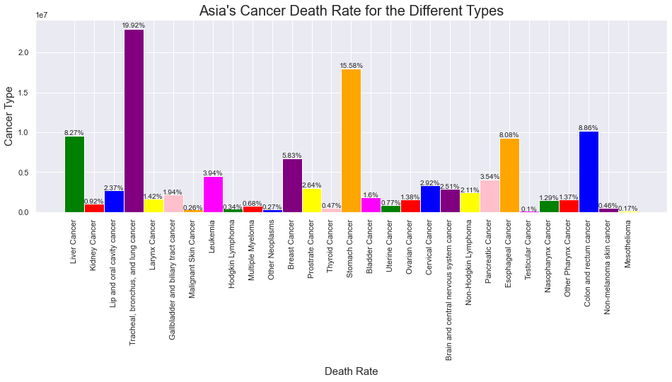

```python
asia_cancer_deaths=np.array(Asia.iloc[:,3:32].sum(axis=0))
ACancerTypes=pd.DataFrame({'Cancer Type':WCancerTypes['Cancer Type'],
                         'Number of Deaths':asia_cancer_deaths})

asia_death_count=Asia['Total Number of Deaths'].sum(axis=0)
percentage=[]
for i in ACancerTypes['Number of Deaths']:
    pct=(i/asia_death_count) * 100
    percentage.append(round(pct,2))
ACancerTypes['Asia %']=percentage

plt.figure(figsize=(16,5))
colors_list=['green','red','blue','purple','yellow','pink','orange','magenta']
cplot=plt.bar(ACancerTypes['Cancer Type'],ACancerTypes['Number of Deaths'],color=colors_list,width=1)

i=0
for p in cplot:
    width=p.get_width()
    height=p.get_height()
    x, y=p.get_xy()
    plt.text(x+width/2,y+height*1.01,str(ACancerTypes['Asia %'][i])+'%', ha='center')
    i+=1

plt.title("Asia's Cancer Death Rate for the Different Types",fontdict={'fontsize':float(20),'fontweight':int(2)})
plt.xlabel('Death Rate',labelpad=float(10),fontdict={'fontsize':float(15),'fontweight':int(2)})
plt.ylabel('Cancer Type',fontdict={'fontsize':float(15),'fontweight':int(2)})
plt.xticks(rotation=90)
plt.grid(True)
```

## DEATH RATE FOR THE DIFFERENT TYPES OF CANCER IN AFRICA

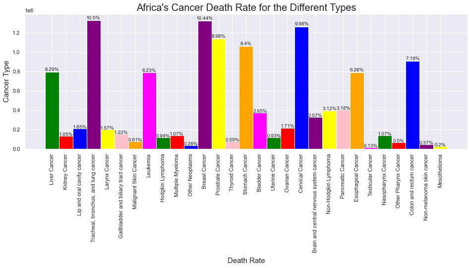

```python
africa_cancer_deaths=np.array(Africa.iloc[:,3:32].sum(axis=0))
AFRCancerTypes=pd.DataFrame({'Cancer Type':WCancerTypes['Cancer Type'],
                         'Number of Deaths':africa_cancer_deaths})

africa_death_count=Africa['Total Number of Deaths'].sum(axis=0)
percentage=[]
for i in AFRCancerTypes['Number of Deaths']:
    pct=(i/africa_death_count) * 100
    percentage.append(round(pct,2))
AFRCancerTypes['Africa %']=percentage

plt.figure(figsize=(16,5))
colors_list=['green','red','blue','purple','yellow','pink','orange','magenta']
cplot=plt.bar(AFRCancerTypes['Cancer Type'],AFRCancerTypes['Number of Deaths'],color=colors_list,width=1)

i=0
for p in cplot:
    width=p.get_width()
    height=p.get_height()
    x, y=p.get_xy()
    plt.text(x+width/2,y+height*1.01,str(AFRCancerTypes['Africa %'][i])+'%', ha='center')
    i+=1

plt.title("Africa's Cancer Death Rate for the Different Types",fontdict={'fontsize':float(20),'fontweight':int(2)})
plt.xlabel('Death Rate',labelpad=float(10),fontdict={'fontsize':float(15),'fontweight':int(2)})
plt.ylabel('Cancer Type',fontdict={'fontsize':float(15),'fontweight':int(2)})
plt.xticks(rotation=90)
plt.grid(True)
```

## DEATH RATE FOR THE DIFFERENT TYPES OF CANCER IN EUROPE

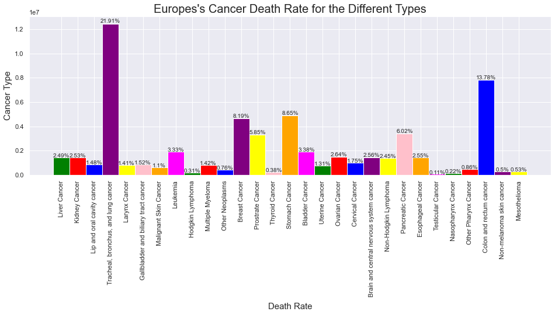

```python
europe_cancer_deaths=np.array(Europe.iloc[:,3:32].sum(axis=0))
ECancerTypes=pd.DataFrame({'Cancer Type':WCancerTypes['Cancer Type'],
                         'Number of Deaths':europe_cancer_deaths})

europe_death_count=Europe['Total Number of Deaths'].sum(axis=0)
percentage=[]
for i in ECancerTypes['Number of Deaths']:
    pct=(i/europe_death_count) * 100
    percentage.append(round(pct,2))
ECancerTypes['Europe %']=percentage

plt.figure(figsize=(16,5))
colors_list=['green','red','blue','purple','yellow','pink','orange','magenta']
cplot=plt.bar(ECancerTypes['Cancer Type'],ECancerTypes['Number of Deaths'],color=colors_list,width=1)

i=0
for p in cplot:
    width=p.get_width()
    height=p.get_height()
    x, y=p.get_xy()
    plt.text(x+width/2,y+height*1.01,str(ECancerTypes['Europe %'][i])+'%', ha='center')
    i+=1

plt.title("Europes's Cancer Death Rate for the Different Types",fontdict={'fontsize':float(20),'fontweight':int(2)})
plt.xlabel('Death Rate',labelpad=float(10),fontdict={'fontsize':float(15),'fontweight':int(2)})
plt.ylabel('Cancer Type',fontdict={'fontsize':float(15),'fontweight':int(2)})
plt.xticks(rotation=90)
plt.grid(True)
```

## DEATH RATE FOR THE DIFFERENT TYPES OF CANCER IN NORTH AMERICA

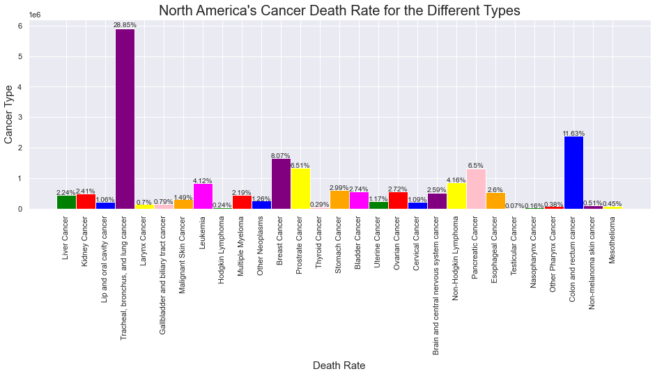

```python
na_cancer_deaths=np.array(NorthAmerica.iloc[:,3:32].sum(axis=0))
NACancerTypes=pd.DataFrame({'Cancer Type':WCancerTypes['Cancer Type'],'Number of Deaths':na_cancer_deaths})

na_death_count=NorthAmerica['Total Number of Deaths'].sum(axis=0)
percentage=[]
for i in NACancerTypes['Number of Deaths']:
    pct=(i/na_death_count) * 100
    percentage.append(round(pct,2))
NACancerTypes['North America %']=percentage

plt.figure(figsize=(16,5))
colors_list=['green','red','blue','purple','yellow','pink','orange','magenta']
cplot=plt.bar(NACancerTypes['Cancer Type'],NACancerTypes['Number of Deaths'],color=colors_list,width=1)

i=0
for p in cplot:
    width=p.get_width()
    height=p.get_height()
    x, y=p.get_xy()
    plt.text(x+width/2,y+height*1.01,str(NACancerTypes['North America %'][i])+'%', ha='center')
    i+=1

plt.title("North America's Cancer Death Rate for the Different Types",fontdict={'fontsize':float(20),'fontweight':int(2)})
plt.xlabel('Death Rate',labelpad=float(10),fontdict={'fontsize':float(15),'fontweight':int(2)})
plt.ylabel('Cancer Type',fontdict={'fontsize':float(15),'fontweight':int(2)})
plt.xticks(rotation=90)
plt.grid(True)
```

## DEATH RATE FOR THE DIFFERENT TYPES OF CANCER IN SOUTH AMERICA

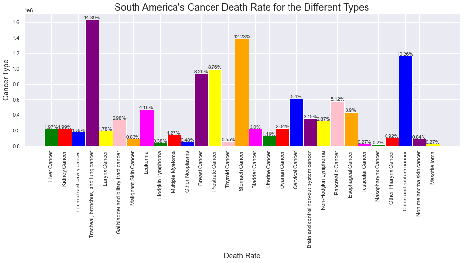

```python
sa_cancer_deaths=np.array(SouthAmerica_DR.iloc[:,3:32].sum(axis=0))
SACancerTypes=pd.DataFrame({'Cancer Type':WCancerTypes['Cancer Type'],
                         'Number of Deaths':sa_cancer_deaths})

sa_death_count=SouthAmerica_DR['Total Number of Deaths'].sum(axis=0)
percentage=[]
for i in SACancerTypes['Number of Deaths']:
    pct=(i/sa_death_count) * 100
    percentage.append(round(pct,2))
SACancerTypes['South America %']=percentage

plt.figure(figsize=(16,5))
colors_list=['green','red','blue','purple','yellow','pink','orange','magenta']
cplot=plt.bar(SACancerTypes['Cancer Type'],SACancerTypes['Number of Deaths'],color=colors_list,width=1)

i=0
for p in cplot:
    width=p.get_width()
    height=p.get_height()
    x, y=p.get_xy()
    plt.text(x+width/2,y+height*1.01,str(SACancerTypes['South America %'][i])+'%', ha='center')
    i+=1

plt.title("South America's Cancer Death Rate for the Different Types",fontdict={'fontsize':float(20),'fontweight':int(2)})
plt.xlabel('Death Rate',labelpad=float(10),fontdict={'fontsize':float(15),'fontweight':int(2)})
plt.ylabel('Cancer Type',fontdict={'fontsize':float(15),'fontweight':int(2)})
plt.xticks(rotation=90)
plt.grid(True)
```

## DEATH RATE FOR THE DIFFERENT TYPES OF CANCER IN OCEANIA

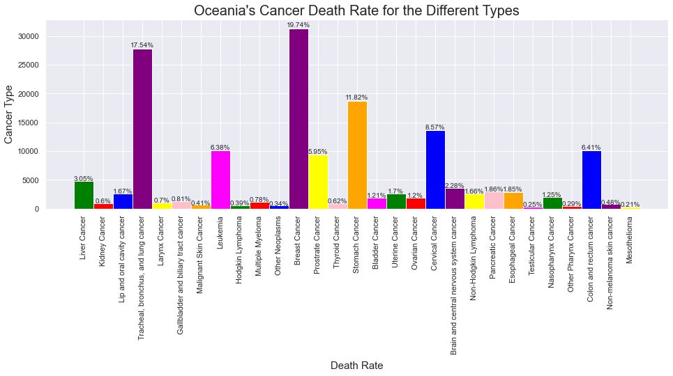

```python
oc_cancer_deaths=np.array(Oceania.iloc[:,3:32].sum(axis=0))
OCancerTypes=pd.DataFrame({'Cancer Type':WCancerTypes['Cancer Type'],
                         'Number of Deaths':oc_cancer_deaths})

oc_death_count=Oceania['Total Number of Deaths'].sum(axis=0)
percentage=[]
for i in OCancerTypes['Number of Deaths']:
    pct=(i/oc_death_count) * 100
    percentage.append(round(pct,2))
OCancerTypes['Oceania %']=percentage

plt.figure(figsize=(16,5))
colors_list=['green','red','blue','purple','yellow','pink','orange','magenta']
cplot=plt.bar(OCancerTypes['Cancer Type'],OCancerTypes['Number of Deaths'],color=colors_list,width=1)

i=0
for p in cplot:
    width=p.get_width()
    height=p.get_height()
    x, y=p.get_xy()
    plt.text(x+width/2,y+height*1.01,str(OCancerTypes['Oceania %'][i])+'%', ha='center')
    i+=1

plt.title("Oceania's Cancer Death Rate for the Different Types",fontdict={'fontsize':float(20),'fontweight':int(2)})
plt.xlabel('Death Rate',labelpad=float(10),fontdict={'fontsize':float(15),'fontweight':int(2)})
plt.ylabel('Cancer Type',fontdict={'fontsize':float(15),'fontweight':int(2)})
plt.xticks(rotation=90)
plt.grid(True)
```

## TABULAR REPRESENTATION OF THE ABOVE BAR CHARTS FOR EACH CONTINENT

```python
OCancerTypes.drop(['Number of Deaths'],axis=1,inplace=True)#This drops 'Number of Deaths' from the columns (axis=1)
ACancerTypes.drop(['Cancer Type','Number of Deaths'],axis=1,inplace=True)
AFRCancerTypes.drop(['Cancer Type','Number of Deaths'],axis=1,inplace=True)
ECancerTypes.drop(['Cancer Type','Number of Deaths'],axis=1,inplace=True)
NACancerTypes.drop(['Cancer Type','Number of Deaths'],axis=1,inplace=True)
SACancerTypes.drop(['Cancer Type','Number of Deaths'],axis=1,inplace=True)
percentage_df=pd.concat([OCancerTypes,AFRCancerTypes,ECancerTypes,NACancerTypes,ACancerTypes,SACancerTypes],axis=1)#This joins DataFrames together
percentage_df
```

|  | Cancer Type | Oceania % | Africa % | Europe % | North America % | Asia % | South America % |
| --- | --- | --- | --- | --- | --- | --- | --- |
| 0 | Liver Cancer | 3.05 | 6.29 | 2.49 | 2.24 | 8.27 | 1.97 |
| 1 | Kidney Cancer | 0.60 | 1.05 | 2.53 | 2.41 | 0.92 | 1.99 |
| 2 | Lip and oral cavity cancer | 1.67 | 1.65 | 1.48 | 1.06 | 2.37 | 1.59 |
| 3 | Tracheal, bronchus, and lung cancer | 17.54 | 10.50 | 21.91 | 28.85 | 19.92 | 14.39 |
| 4 | Larynx Cancer | 0.70 | 1.57 | 1.41 | 0.70 | 1.42 | 1.78 |
| 5 | Gallbladder and biliary tract cancer | 0.81 | 1.22 | 1.52 | 0.79 | 1.94 | 2.98 |
| 6 | Malignant Skin Cancer | 0.41 | 0.61 | 1.10 | 1.49 | 0.26 | 0.83 |
| 7 | Leukemia | 6.38 | 6.23 | 3.33 | 4.12 | 3.94 | 4.16 |
| 8 | Hodgkin Lymphoma | 0.39 | 0.94 | 0.31 | 0.24 | 0.34 | 0.38 |
| 9 | Multiple Myeloma | 0.78 | 1.07 | 1.42 | 2.19 | 0.68 | 1.27 |
| 10 | Other Neoplasms | 0.34 | 0.28 | 0.76 | 1.26 | 0.27 | 0.48 |
| 11 | Breast Cancer | 19.74 | 10.44 | 8.19 | 8.07 | 5.83 | 8.26 |
| 12 | Prostrate Cancer | 5.95 | 8.98 | 5.85 | 6.51 | 2.64 | 8.76 |
| 13 | Thyroid Cancer | 0.62 | 0.59 | 0.38 | 0.29 | 0.47 | 0.55 |
| 14 | Stomach Cancer | 11.82 | 8.40 | 8.65 | 2.99 | 15.58 | 12.23 |
| 15 | Bladder Cancer | 1.21 | 2.95 | 3.38 | 2.74 | 1.60 | 2.00 |
| 16 | Uterine Cancer | 1.70 | 0.93 | 1.31 | 1.17 | 0.77 | 1.16 |
| 17 | Ovarian Cancer | 1.20 | 1.71 | 2.64 | 2.72 | 1.38 | 2.04 |
| 18 | Cervical Cancer | 8.57 | 9.98 | 1.75 | 1.09 | 2.92 | 5.40 |
| 19 | Brain and central nervous system cancer | 2.28 | 2.57 | 2.56 | 2.59 | 2.51 | 3.15 |
| 20 | Non-Hodgkin Lymphoma | 1.66 | 3.12 | 2.45 | 4.16 | 2.11 | 2.87 |
| 21 | Pancreatic Cancer | 1.86 | 3.18 | 6.02 | 6.50 | 3.54 | 5.12 |
| 22 | Esophageal Cancer | 1.85 | 6.26 | 2.55 | 2.60 | 8.08 | 3.90 |
| 23 | Testicular Cancer | 0.25 | 0.13 | 0.11 | 0.07 | 0.10 | 0.27 |
| 24 | Nasopharynx Cancer | 1.25 | 1.07 | 0.22 | 0.16 | 1.29 | 0.20 |
| 25 | Other Pharynx Cancer | 0.29 | 0.50 | 0.86 | 0.38 | 1.37 | 0.92 |
| 26 | Colon and rectum cancer | 6.41 | 7.19 | 13.78 | 11.63 | 8.86 | 10.26 |
| 27 | Non-melanoma skin cancer | 0.48 | 0.37 | 0.50 | 0.51 | 0.46 | 0.84 |
| 28 | Mesothelioma | 0.21 | 0.20 | 0.53 | 0.45 | 0.17 | 0.27 |

The above is just a tabular representation of the bar charts for the different continents.

This table shows the percentage of people that died from a particular cancer type, in a particular continent and also the total percentage of deaths.